# Description of dataset

Nikita Barsukov

This text is a part of a series of writings where I try various regression algorithms on the same dataset. Dataset is a house prices sold in Seattle area in 2014-15. This text is about dataset itself. Other writeups in this series are about how ordinary least squares and support vector machines algorithms worked to predict prices. There is also a text about whether using robust feature selection techniques makes a difference in training a price prediction alforithm.

It is a good idea to get acquainted with the dataset before developing a regression model, so let’s do this before getting hands dirty with actual machine learning.

Original dataset contains 21,613 house sales, each sale has 21 columns. Columns are straightforward. All expected characteristics like living area, geographic coordinates of a house, zip code, year of building and renovation, and many more.

Houses in the dataset are scattered across most of King’s county, where Seattle is located, but concentrated in Seattle’s northern part.

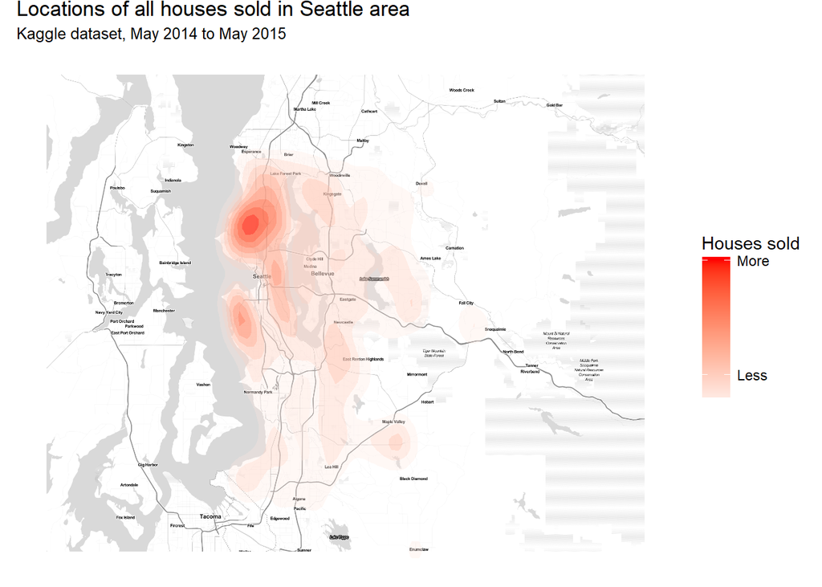

Let’s look at how various types of houses are distributed on a map. For example, sold houses are distributed on a map differently, depending on number of bedrooms.

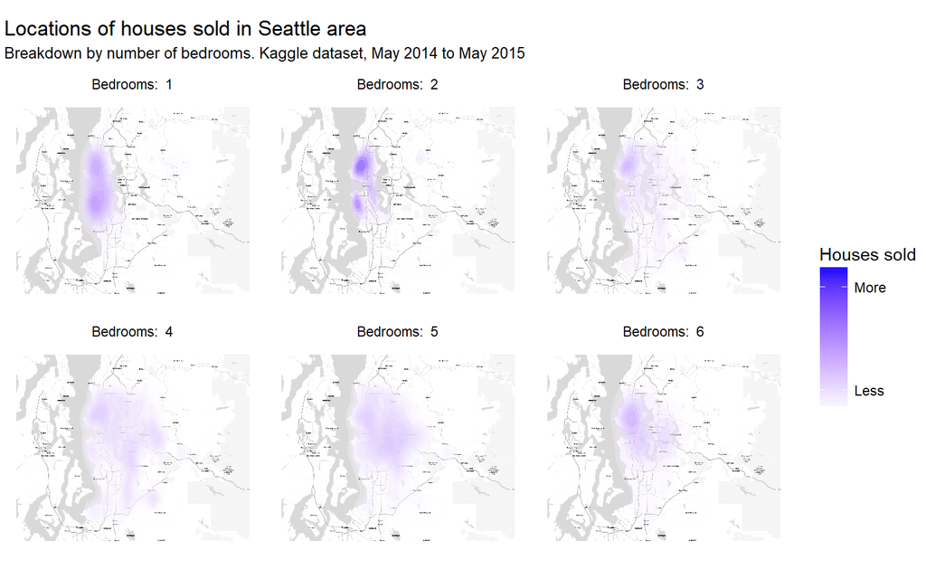

WHen we look at a house grade, we also see differences in house locations by its grade:

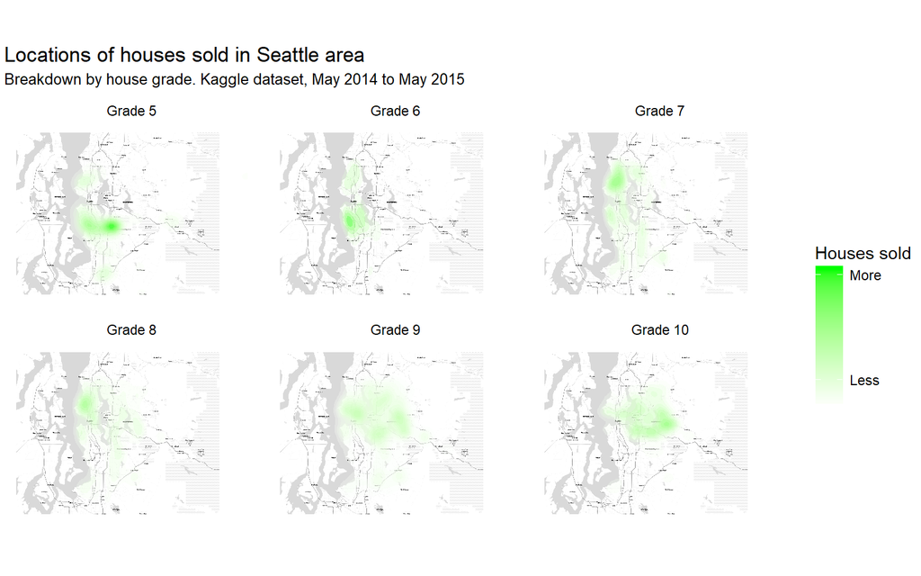